# linear model project

Jason Rivera

November 20, 2019

# Introduction

This data was taken from http://onlinestatbook.com/case_studies_rvls/physical_strength/index.html The data set contains observations from job applications on their sim score arm strength, grip and rating.

We write there models:

1. sims = f(arm)
2. sims = f(grip)
3. sims = f(arm,grip)

## First Model

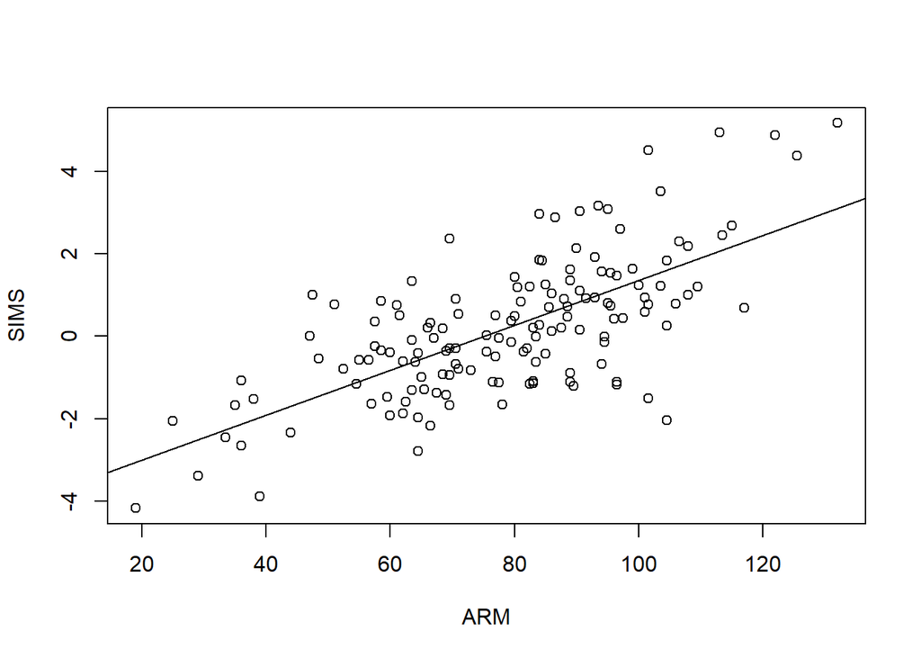

```r
model1 = lm(SIMS~ARM)
# scatterplot
plot(ARM, SIMS)
abline(model1)
```

```r
#numeric summary
summary.lm(model1)
```

```
##
## Call:
## lm(formula = SIMS ~ ARM)
##
## Residuals:
##     Min      1Q  Median      3Q     Max
## -3.6467 -0.7502 -0.0285  0.6875  3.0770
##
## Coefficients:
##              Estimate Std. Error t value Pr(>|t|)
## (Intercept) -4.095160   0.391745  -10.45   <2e-16 ***
## ARM          0.054563   0.004806   11.35   <2e-16 ***
## ---
## Signif. codes:  0 '***' 0.001 '**' 0.01 '*' 0.05 '.' 0.1 ' ' 1
##
## Residual standard error: 1.226 on 145 degrees of freedom
## Multiple R-squared:  0.4706, Adjusted R-squared:  0.467
## F-statistic: 128.9 on 1 and 145 DF,  p-value: < 2.2e-16
```

This scatterplot shows the higher your arm strength the the higher your sim score but it is not entirely accurate.

The prediction interval for model 1 when arm=94, grip=88 is:

```r
newdata = data.frame(ARM=94, GRIP=88)
predict(model1, newdata, interval='prediction')
```

```
##        fit       lwr      upr
## 1 1.033762 -1.401556 3.469079
```

If your arm strength is 94 then we predict you’ll have an average sim score between -1.401556 and 3.469079

## Second Model

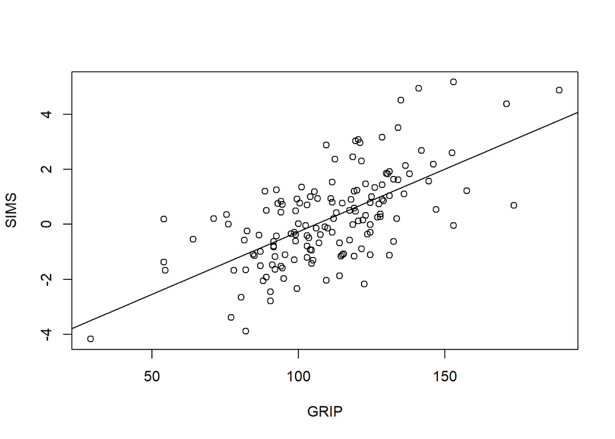

```r
model2 = lm(SIMS~GRIP)
# scatterplot
plot(GRIP, SIMS)
abline(model2)
```

```r
#numeric summary
summary.lm(model2)
```

```
##
## Call:
## lm(formula = SIMS ~ GRIP)
##
## Residuals:
##     Min      1Q  Median      3Q     Max
## -2.9295 -0.8708 -0.1219  0.8039  3.3494
##
## Coefficients:
##              Estimate Std. Error t value Pr(>|t|)
## (Intercept) -4.809675   0.511141   -9.41   <2e-16 ***
## GRIP         0.045463   0.004535   10.03   <2e-16 ***
## ---
## Signif. codes:  0 '***' 0.001 '**' 0.01 '*' 0.05 '.' 0.1 ' ' 1
##
## Residual standard error: 1.295 on 145 degrees of freedom
## Multiple R-squared:  0.4094, Adjusted R-squared:  0.4053
## F-statistic: 100.5 on 1 and 145 DF,  p-value: < 2.2e-16
```

This scatterplot shows that the stronger the grip the higher the sims, but its not entirely accurate.

The prediction interval for model 2 when arm=94, grip=88 is:

```r
predict(model2, newdata, interval='prediction')
```

```
##          fit      lwr      upr
## 1 -0.8089323 -3.38434 1.766475
```

If your grip score is 88 we predict your average sim score will be between -3.38434 and 1.766475

## Third Model

```r
model3 = lm(SIMS~ARM+GRIP)
#numeric summary
summary.lm(model3)
```

```
##
## Call:
## lm(formula = SIMS ~ ARM + GRIP)
##
## Residuals:
##     Min      1Q  Median      3Q     Max
## -3.1846 -0.7380 -0.0641  0.7394  2.8634
##
## Coefficients:
##              Estimate Std. Error t value Pr(>|t|)
## (Intercept) -5.433871   0.461815 -11.766  < 2e-16 ***
## ARM          0.037311   0.005774   6.462 1.50e-09 ***
## GRIP         0.024470   0.005158   4.744 4.99e-06 ***
## ---
## Signif. codes:  0 '***' 0.001 '**' 0.01 '*' 0.05 '.' 0.1 ' ' 1
##
## Residual standard error: 1.144 on 144 degrees of freedom
## Multiple R-squared:  0.5422, Adjusted R-squared:  0.5358
## F-statistic: 85.26 on 2 and 144 DF,  p-value: < 2.2e-16
```

```r
predict(model3, newdata, interval='prediction')
```

```
##         fit       lwr      upr
## 1 0.2266909 -2.070793 2.524175
```

Having an arm strength of 94 and grip of 88 gives you and average sim score between -2.070793 and 2.524175

```r
anova(model1, model3)
```

```
## Analysis of Variance Table
##
## Model 1: SIMS ~ ARM
## Model 2: SIMS ~ ARM + GRIP
##   Res.Df    RSS Df Sum of Sq      F    Pr(>F)
## 1    145 217.88
## 2    144 188.43  1     29.45 22.506 4.994e-06 ***
## ---
## Signif. codes:  0 '***' 0.001 '**' 0.01 '*' 0.05 '.' 0.1 ' ' 1
```

model 3 is a better predictor using arm strength and grip than just using arm strength.